# MovieLens Project Questions

### `Project - MovieLens Data Analysis`

The GroupLens Research Project is a research group in the Department of Computer Science and Engineering at the University of Minnesota. The data is widely used for collaborative filtering and other filtering solutions. However, we will be using this data to act as a means to demonstrate our skill in using Python to “play” with data.

### `Objective:`

- To implement the techniques learnt as a part of the course.

### `Learning Outcomes:`

- Exploratory Data Analysis
- Visualization using Python
- Pandas – groupby, merging

### `Domain`

- Internet and Entertainment

**Note that the project will need you to apply the concepts of groupby and merging extensively.**

### `Datasets Information:`

*rating.csv:* It contains information on ratings given by the users to a particular movie.

- user id: id assigned to every user
- movie id: id assigned to every movie
- rating: rating given by the user
- timestamp: Time recorded when the user gave a rating

*movie.csv:* File contains information related to the movies and their genre.

- movie id: id assigned to every movie
- movie title: Title of the movie
- release date: Date of release of the movie
- Action: Genre containing binary values (1 - for action 0 - not action)
- Adventure: Genre containing binary values (1 - for adventure 0 - not adventure)
- Animation: Genre containing binary values (1 - for animation 0 - not animation)
- Children’s: Genre containing binary values (1 - for children's 0 - not children's)
- Comedy: Genre containing binary values (1 - for comedy 0 - not comedy)
- Crime: Genre containing binary values (1 - for crime 0 - not crime)
- Documentary: Genre containing binary values (1 - for documentary 0 - not documentary)
- Drama: Genre containing binary values (1 - for drama 0 - not drama)
- Fantasy: Genre containing binary values (1 - for fantasy 0 - not fantasy)
- Film-Noir: Genre containing binary values (1 - for film-noir 0 - not film-noir)
- Horror: Genre containing binary values (1 - for horror 0 - not horror)
- Musical: Genre containing binary values (1 - for musical 0 - not musical)
- Mystery: Genre containing binary values (1 - for mystery 0 - not mystery)
- Romance: Genre containing binary values (1 - for romance 0 - not romance)
- Sci-Fi: Genre containing binary values (1 - for sci-fi 0 - not sci-fi)
- Thriller: Genre containing binary values (1 - for thriller 0 - not thriller)
- War: Genre containing binary values (1 - for war 0 - not war)
- Western: Genre containing binary values (1 - for western - not western)

*user.csv:* It contains information of the users who have rated the movies.

- user id: id assigned to every user
- age: Age of the user
- gender: Gender of the user
- occupation: Occupation of the user
- zip code: Zip code of the use

**`Please provide you insights wherever necessary.`**

### 1. Import the necessary packages - 2.5 marks

```python
import numpy as np
import pandas as pd
import matplotlib.pyplot as plt
import seaborn as sns
sns.set(color_codes=True)
%matplotlib inline
import warnings
warnings.filterwarnings("ignore")
from PIL import Image
```

### 2. Read the 3 datasets into dataframes - 2.5 marks

```python
ratingdata = pd.read_csv('data.csv')
moviedata = pd.read_csv('item.csv')
userdata = pd.read_csv('user.csv')
```

### 3. Apply info, shape, describe, and find the number of missing values in the data - 5 marks

- Note that you will need to do it for all the three datasets seperately

```python
ratingdata.info()
```

```
<class 'pandas.core.frame.DataFrame'>
RangeIndex: 100000 entries, 0 to 99999
Data columns (total 4 columns):
 #   Column     Non-Null Count   Dtype
---  ------     --------------   -----
 0   user id    100000 non-null  int64
 1   movie id   100000 non-null  int64
 2   rating     100000 non-null  int64
 3   timestamp  100000 non-null  int64
dtypes: int64(4)
memory usage: 3.1 MB
```

```python
ratingdata.shape
```

```
(100000, 4)
```

```python
ratingdata.describe
```

```
<bound method NDFrame.describe of        user id  movie id  rating  timestamp
0          196       242       3  881250949
1          186       302       3  891717742
2           22       377       1  878887116
3          244        51       2  880606923
4          166       346       1  886397596
...        ...       ...     ...        ...
99995      880       476       3  880175444
99996      716       204       5  879795543
99997      276      1090       1  874795795
99998       13       225       2  882399156
99999       12       203       3  879959583

[100000 rows x 4 columns]>
```

```python
ratingdata.isnull().sum()
```

```
user id      0
movie id     0
rating       0
timestamp    0
dtype: int64
```

### 'Second dataset'

```python
moviedata.info()
```

```
<class 'pandas.core.frame.DataFrame'>
RangeIndex: 1681 entries, 0 to 1680
Data columns (total 22 columns):
 #   Column        Non-Null Count  Dtype
---  ------        --------------  -----
 0   movie id      1681 non-null   int64
 1   movie title   1681 non-null   object
 2   release date  1681 non-null   object
 3   unknown       1681 non-null   int64
 4   Action        1681 non-null   int64
 5   Adventure     1681 non-null   int64
 6   Animation     1681 non-null   int64
 7   Childrens     1681 non-null   int64
 8   Comedy        1681 non-null   int64
 9   Crime         1681 non-null   int64
 10  Documentary   1681 non-null   int64
 11  Drama         1681 non-null   int64
 12  Fantasy       1681 non-null   int64
 13  Film-Noir     1681 non-null   int64
 14  Horror        1681 non-null   int64
 15  Musical       1681 non-null   int64
 16  Mystery       1681 non-null   int64
 17  Romance       1681 non-null   int64
 18  Sci-Fi        1681 non-null   int64
 19  Thriller      1681 non-null   int64
 20  War           1681 non-null   int64
 21  Western       1681 non-null   int64
dtypes: int64(20), object(2)
memory usage: 289.0+ KB
```

```python
moviedata.shape
```

```
(1681, 22)
```

```python
moviedata.describe
```

```
<bound method NDFrame.describe of       movie id                          movie title release date  unknown  \
0            1                           Toy Story   01-Jan-1995        0
1            2                           GoldenEye   01-Jan-1995        0
2            3                          Four Rooms   01-Jan-1995        0
3            4                          Get Shorty   01-Jan-1995        0
4            5                             Copycat   01-Jan-1995        0
...        ...                                  ...          ...      ...
1676      1678                          Mat' i syn   06-Feb-1998        0
1677      1679                           B. Monkey   06-Feb-1998        0
1678      1680                       Sliding Doors   01-Jan-1998        0
1679      1681                        You So Crazy   01-Jan-1994        0
1680      1682  Scream of Stone (Schrei aus Stein)   08-Mar-1996        0

      Action  Adventure  Animation  Childrens  Comedy  Crime  ...  Fantasy  \
0          0          0          1          1       1      0  ...        0
```

[output cut: 38 more lines]

```python
moviedata.isnull().sum()
```

```
movie id        0
movie title     0
release date    0
unknown         0
Action          0
Adventure       0
Animation       0
Childrens       0
Comedy          0
Crime           0
Documentary     0
Drama           0
Fantasy         0
Film-Noir       0
Horror          0
Musical         0
Mystery         0
Romance         0
Sci-Fi          0
Thriller        0
War             0
Western         0
dtype: int64
```

```python
moviedata['release date'].isnull().count()
```

```
1681
```

### 'Third dataset'

```python
userdata.info()
```

```
<class 'pandas.core.frame.DataFrame'>
RangeIndex: 943 entries, 0 to 942
Data columns (total 5 columns):
 #   Column      Non-Null Count  Dtype
---  ------      --------------  -----
 0   user id     943 non-null    int64
 1   age         943 non-null    int64
 2   gender      943 non-null    object
 3   occupation  943 non-null    object
 4   zip code    943 non-null    object
dtypes: int64(2), object(3)
memory usage: 37.0+ KB
```

```python
userdata.shape
```

```
(943, 5)
```

```python
userdata.describe
```

```
<bound method NDFrame.describe of      user id  age gender     occupation zip code
0          1   24      M     technician    85711
1          2   53      F          other    94043
2          3   23      M         writer    32067
3          4   24      M     technician    43537
4          5   33      F          other    15213
..       ...  ...    ...            ...      ...
938      939   26      F        student    33319
939      940   32      M  administrator    02215
940      941   20      M        student    97229
941      942   48      F      librarian    78209
942      943   22      M        student    77841

[943 rows x 5 columns]>
```

```python
userdata.isnull().sum()
```

```
user id       0
age           0
gender        0
occupation    0
zip code      0
dtype: int64
```

### 4. Find the number of movies per genre using the item data - 2.5 marks

```python
#Calculating total number of movies per Genre
print("Number of Action Movies=",moviedata['Action'].sum())
print("Number of Adventure Movies=",moviedata['Adventure'].sum())
print("Number of Animation Movies=",moviedata['Animation'].sum())
print("Number of Childrens Movies=",moviedata['Childrens'].sum())
print("Number of Comedy Movies=",moviedata['Comedy'].sum())
print("Number of Crime Movies=",moviedata['Crime'].sum())
print("Number of Documentary Movies=",moviedata['Documentary'].sum())
print("Number of Drama Movies=",moviedata['Drama'].sum())
print("Number of Fantasy Movies=",moviedata['Fantasy'].sum())
print("Number of Film-Noir Movies=",moviedata['Film-Noir'].sum())
print("Number of Horror Movies=",moviedata['Horror'].sum())
print("Number of Musical Movies=",moviedata['Musical'].sum())
print("Number of Mystery Movies=",moviedata['Mystery'].sum())
print("Number of Romance Movies=",moviedata['Romance'].sum())
print("Number of Sci-Fi Movies=",moviedata['Sci-Fi'].sum())
print("Number of Thriller Movies=",moviedata['Thriller'].sum())
print("Number of War Movies=",moviedata['War'].sum())
print("Number of Western Movies=",moviedata['Western'].sum())
```

```
Number of Action Movies= 251
Number of Adventure Movies= 135
Number of Animation Movies= 42
Number of Childrens Movies= 122
Number of Comedy Movies= 505
Number of Crime Movies= 109
Number of Documentary Movies= 50
Number of Drama Movies= 725
Number of Fantasy Movies= 22
Number of Film-Noir Movies= 24
Number of Horror Movies= 92
Number of Musical Movies= 56
Number of Mystery Movies= 61
Number of Romance Movies= 247
Number of Sci-Fi Movies= 101
Number of Thriller Movies= 251
Number of War Movies= 71
Number of Western Movies= 27
```

### 5. Drop the movie where the genre is unknown - 2.5 marks

```python
#Creating new colun with sum of all genres for a movie
sum_column=moviedata['Action']+moviedata['Adventure']+moviedata['Animation']+moviedata['Childrens']+moviedata['Comedy']+moviedata['Crime']+moviedata['Documentary']+moviedata['Drama']+moviedata['Fantasy']+moviedata['Film-Noir']+moviedata['Horror']+moviedata['Musical']+moviedata['Mystery']+moviedata['Romance']+moviedata['Sci-Fi']+moviedata['Thriller']+moviedata['War']+moviedata['Western']
```

```python
#Adding Total genre column in the dataset
moviedata["Total_genre"]=sum_column
```

```python
moviedata.describe
```

```
<bound method NDFrame.describe of       movie id                          movie title release date  unknown  \
0            1                           Toy Story   01-Jan-1995        0
1            2                           GoldenEye   01-Jan-1995        0
2            3                          Four Rooms   01-Jan-1995        0
3            4                          Get Shorty   01-Jan-1995        0
4            5                             Copycat   01-Jan-1995        0
...        ...                                  ...          ...      ...
1676      1678                          Mat' i syn   06-Feb-1998        0
1677      1679                           B. Monkey   06-Feb-1998        0
1678      1680                       Sliding Doors   01-Jan-1998        0
1679      1681                        You So Crazy   01-Jan-1994        0
1680      1682  Scream of Stone (Schrei aus Stein)   08-Mar-1996        0

      Action  Adventure  Animation  Childrens  Comedy  Crime  ...  Film-Noir  \
0          0          0          1          1       1      0  ...          0
```

[output cut: 38 more lines]

```python
#Movie with unkown genre, thats is where all genres are '0'
moviedata[moviedata.Total_genre==0].sum()
```

```
movie id                 1373
movie title     Good Morning
release date       4-Feb-1971
unknown                     1
Action                      0
Adventure                   0
Animation                   0
Childrens                   0
Comedy                      0
Crime                       0
Documentary                 0
Drama                       0
Fantasy                     0
Film-Noir                   0
Horror                      0
Musical                     0
Mystery                     0
Romance                     0
Sci-Fi                      0
Thriller                    0
War                         0
Western                     0
Total_genre                 0
dtype: object
```

```python
#Drop the movie where Genre is unknown
moviedata.drop(moviedata[moviedata.Total_genre==0].index,inplace=True)
moviedata.info
```

```
<bound method DataFrame.info of       movie id                          movie title release date  unknown  \
0            1                           Toy Story   01-Jan-1995        0
1            2                           GoldenEye   01-Jan-1995        0
2            3                          Four Rooms   01-Jan-1995        0
3            4                          Get Shorty   01-Jan-1995        0
4            5                             Copycat   01-Jan-1995        0
...        ...                                  ...          ...      ...
1676      1678                          Mat' i syn   06-Feb-1998        0
1677      1679                           B. Monkey   06-Feb-1998        0
1678      1680                       Sliding Doors   01-Jan-1998        0
1679      1681                        You So Crazy   01-Jan-1994        0
1680      1682  Scream of Stone (Schrei aus Stein)   08-Mar-1996        0

      Action  Adventure  Animation  Childrens  Comedy  Crime  ...  Film-Noir  \
0          0          0          1          1       1      0  ...          0
```

[output cut: 38 more lines]

### 6. Find the movies that have more than one genre - 5 marks

hint: use sum on the axis = 1

Display movie name, number of genres for the movie in dataframe

and also print(total number of movies which have more than one genres)

```python
#List of movies with more than one Genre
moviedata3=moviedata[moviedata.Total_genre>1]
moviedata3[['movie title','Total_genre']]
```

|  | movie title | Total_genre |
| --- | --- | --- |
| 0 | Toy Story | 3 |
| 1 | GoldenEye | 3 |
| 3 | Get Shorty | 3 |
| 4 | Copycat | 3 |
| 6 | Twelve Monkeys | 2 |
| ... | ... | ... |
| 1667 | MURDER and murder | 3 |
| 1668 | Tainted | 2 |
| 1671 | Mirage | 2 |
| 1677 | B. Monkey | 2 |
| 1678 | Sliding Doors | 2 |

849 rows × 2 columns

```python
#Total number of movies with more than one genre

print("Total number of movies with more than one genre=",moviedata3['movie title'].count())
```

```
Total number of movies with more than one genre= 849
```

### 7. Univariate plots of columns: 'rating', 'Age', 'release year', 'Gender' and 'Occupation' - 10 marks

*HINT: Use distplot for age. Use lineplot or countplot for release year.*

*HINT: Plot percentages in y-axis and categories in x-axis for ratings, gender and occupation*

*HINT: Please refer to the below snippet to understand how to get to release year from release date. You can use str.split() as depicted below or you could convert it to pandas datetime format and extract year (.dt.year)*

```python
a = 'My*cat*is*brown'
print(a.split('*')[3])

#similarly, the release year needs to be taken out from release date

#also you can simply slice existing string to get the desired data, if we want to take out the colour of the cat

print(a[10:])
print(a[-5:])
```

```
brown
brown
brown
```

```python
#Converting to Pandas date time format and adding a separate column for release year
moviedata['release date'] = pd.to_datetime(moviedata['release date'],format = '%d-%b-%Y')
moviedata['release year'] = pd.to_datetime(moviedata['release date'],format ='%d-%b-%Y').dt.year
```

```python
moviedata.head(10)
```

|  | movie id | movie title | release date | unknown | Action | Adventure | Animation | Childrens | Comedy | Crime | ... | Horror | Musical | Mystery | Romance | Sci-Fi | Thriller | War | Western | Total_genre | release year |
| --- | --- | --- | --- | --- | --- | --- | --- | --- | --- | --- | --- | --- | --- | --- | --- | --- | --- | --- | --- | --- | --- |
| 0 | 1 | Toy Story | 1995-01-01 | 0 | 0 | 0 | 1 | 1 | 1 | 0 | ... | 0 | 0 | 0 | 0 | 0 | 0 | 0 | 0 | 3 | 1995 |
| 1 | 2 | GoldenEye | 1995-01-01 | 0 | 1 | 1 | 0 | 0 | 0 | 0 | ... | 0 | 0 | 0 | 0 | 0 | 1 | 0 | 0 | 3 | 1995 |
| 2 | 3 | Four Rooms | 1995-01-01 | 0 | 0 | 0 | 0 | 0 | 0 | 0 | ... | 0 | 0 | 0 | 0 | 0 | 1 | 0 | 0 | 1 | 1995 |
| 3 | 4 | Get Shorty | 1995-01-01 | 0 | 1 | 0 | 0 | 0 | 1 | 0 | ... | 0 | 0 | 0 | 0 | 0 | 0 | 0 | 0 | 3 | 1995 |
| 4 | 5 | Copycat | 1995-01-01 | 0 | 0 | 0 | 0 | 0 | 0 | 1 | ... | 0 | 0 | 0 | 0 | 0 | 1 | 0 | 0 | 3 | 1995 |
| 5 | 6 | Shanghai Triad (Yao a yao yao dao waipo qiao) | 1995-01-01 | 0 | 0 | 0 | 0 | 0 | 0 | 0 | ... | 0 | 0 | 0 | 0 | 0 | 0 | 0 | 0 | 1 | 1995 |
| 6 | 7 | Twelve Monkeys | 1995-01-01 | 0 | 0 | 0 | 0 | 0 | 0 | 0 | ... | 0 | 0 | 0 | 0 | 1 | 0 | 0 | 0 | 2 | 1995 |
| 7 | 8 | Babe | 1995-01-01 | 0 | 0 | 0 | 0 | 1 | 1 | 0 | ... | 0 | 0 | 0 | 0 | 0 | 0 | 0 | 0 | 3 | 1995 |
| 8 | 9 | Dead Man Walking | 1995-01-01 | 0 | 0 | 0 | 0 | 0 | 0 | 0 | ... | 0 | 0 | 0 | 0 | 0 | 0 | 0 | 0 | 1 | 1995 |
| 9 | 10 | Richard III | 1996-01-22 | 0 | 0 | 0 | 0 | 0 | 0 | 0 | ... | 0 | 0 | 0 | 0 | 0 | 0 | 1 | 0 | 2 | 1996 |

10 rows × 24 columns

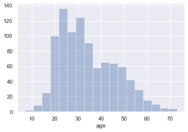

```python
#Univariate plot for Age
sns.distplot(userdata['age'],kde=False)
```

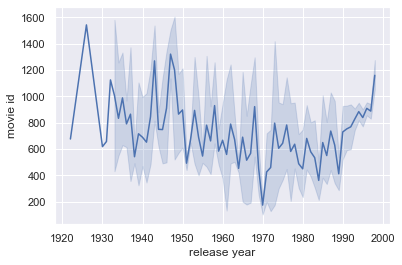

```python
#Plot for movie release year
sns.lineplot(x=moviedata['release year'],y=moviedata['movie id'],data=moviedata)
```

```
[Text(0, 0.5, 'Percent')]
```

[figure not shown]

```python
#Plot for movie ratings with respect to percentage on y axis
df1=ratingdata['rating']
ax.set(ylabel="Percent")
ax = sns.barplot(x=df1, y=df1, data=df1, estimator=lambda x: len(x) / len(df1) * 100)
ax.set(ylabel="Percent")
```

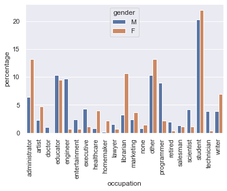

```python
#Plot for occupation on x axis with gender as hue and percentage on y axis
grouped = userdata.groupby(['gender'], sort=False)
occupation_counts = grouped['occupation'].value_counts(normalize=True, sort=False)

occupation_data = [
    {'occupation': occupation, 'gender': gender, 'percentage': percentage*100} for
    (gender, occupation), percentage in dict(occupation_counts).items()
]

df_occupation = pd.DataFrame(occupation_data)

p = sns.barplot(x="occupation", y="percentage", hue="gender", data=df_occupation)
_ = plt.setp(p.get_xticklabels(), rotation=90)  # Rotate labels
```

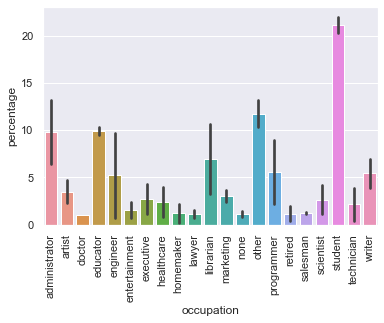

```python
#percentage plot for occupation only
p = sns.barplot(x="occupation", y="percentage", data=df_occupation)
_ = plt.setp(p.get_xticklabels(), rotation=90)  # Rotate labels
```

### 8. Visualize how popularity of genres has changed over the years - 10 marks

Note that you need to use the **percent of number of releases in a year** as a parameter of popularity of a genre

Hint 1: You need to reach to a data frame where the release year is the index and the genre is the column names (one cell shows the number of release in a year in one genre) or vice versa. (Drop unnecessary column if there are any)

Hint 2: Find the total number of movies release in a year(use `sum(axis=1)` store that value in a new column as 'total'). Now divide the value of each genre in that year by total to get percentage number of release in a particular year. `(df.div(df['total'], axis= 0) * 100)`

Once that is achieved, you can either use univariate plots or can use the heatmap to visualise all the changes over the years in one go.

Hint 3: Use groupby on the relevant column and use sum() on the same to find out the number of releases in a year/genre.

```python
#Total number of movie releases per year
tot_movies_by_year = moviedata[['movie id', 'release year']].groupby('release year').count()
tot_movies_by_year.columns=["total releases"]
tot_movies_by_year.head(10)
```

| release year | total releases |
| --- | --- |
| 1922 | 1 |
| 1926 | 1 |
| 1930 | 1 |
| 1931 | 1 |
| 1932 | 1 |
| 1933 | 2 |
| 1934 | 4 |
| 1935 | 4 |
| 1936 | 2 |
| 1937 | 4 |

```python
#Total number of movie releases per year per genre
tot_movie_per_yr_per_genre=moviedata[['Drama', 'Fantasy', 'Film-Noir', 'Horror', 'Musical', 'Mystery','Romance', 'Sci-Fi', 'Thriller', 'War', 'Western','release year']].groupby('release year').sum()
tot_movie_per_yr_per_genre.tail(15)
```

| release year | Drama | Fantasy | Film-Noir | Horror | Musical | Mystery | Romance | Sci-Fi | Thriller | War | Western |
| --- | --- | --- | --- | --- | --- | --- | --- | --- | --- | --- | --- |
| 1984 | 5 | 0 | 0 | 1 | 1 | 1 | 0 | 2 | 2 | 1 | 0 |
| 1985 | 3 | 0 | 0 | 0 | 0 | 0 | 1 | 2 | 1 | 1 | 0 |
| 1986 | 8 | 0 | 0 | 2 | 0 | 0 | 2 | 3 | 2 | 3 | 0 |
| 1987 | 5 | 1 | 0 | 3 | 1 | 0 | 4 | 0 | 1 | 1 | 0 |
| 1988 | 3 | 0 | 0 | 0 | 0 | 0 | 2 | 1 | 3 | 0 | 1 |
| 1989 | 8 | 0 | 0 | 0 | 0 | 0 | 1 | 2 | 2 | 2 | 0 |
| 1990 | 12 | 0 | 1 | 1 | 0 | 0 | 4 | 0 | 4 | 0 | 2 |
| 1991 | 11 | 1 | 0 | 1 | 2 | 0 | 0 | 4 | 3 | 1 | 0 |
| 1992 | 14 | 0 | 0 | 6 | 1 | 1 | 7 | 3 | 5 | 2 | 1 |
| 1993 | 64 | 0 | 1 | 5 | 2 | 6 | 16 | 8 | 17 | 4 | 2 |
| 1994 | 97 | 3 | 0 | 8 | 2 | 2 | 35 | 7 | 25 | 7 | 6 |
| 1995 | 89 | 3 | 1 | 14 | 3 | 5 | 37 | 15 | 39 | 5 | 2 |
| 1996 | 170 | 6 | 1 | 11 | 9 | 6 | 38 | 15 | 47 | 9 | 2 |
| 1997 | 113 | 4 | 2 | 8 | 5 | 18 | 51 | 13 | 54 | 14 | 0 |
| 1998 | 33 | 1 | 2 | 4 | 1 | 3 | 11 | 5 | 18 | 0 | 0 |

```python
#Adding column for total number of release per year to above dataset
tot_movie_per_yr_per_genre['total releases'] = pd.DataFrame(tot_movies_by_year["total releases"])
tot_movie_per_yr_per_genre.tail(15)
```

| release year | Drama | Fantasy | Film-Noir | Horror | Musical | Mystery | Romance | Sci-Fi | Thriller | War | Western | total releases |
| --- | --- | --- | --- | --- | --- | --- | --- | --- | --- | --- | --- | --- |
| 1984 | 5 | 0 | 0 | 1 | 1 | 1 | 0 | 2 | 2 | 1 | 0 | 8 |
| 1985 | 3 | 0 | 0 | 0 | 0 | 0 | 1 | 2 | 1 | 1 | 0 | 7 |
| 1986 | 8 | 0 | 0 | 2 | 0 | 0 | 2 | 3 | 2 | 3 | 0 | 15 |
| 1987 | 5 | 1 | 0 | 3 | 1 | 0 | 4 | 0 | 1 | 1 | 0 | 13 |
| 1988 | 3 | 0 | 0 | 0 | 0 | 0 | 2 | 1 | 3 | 0 | 1 | 11 |
| 1989 | 8 | 0 | 0 | 0 | 0 | 0 | 1 | 2 | 2 | 2 | 0 | 15 |
| 1990 | 12 | 0 | 1 | 1 | 0 | 0 | 4 | 0 | 4 | 0 | 2 | 24 |
| 1991 | 11 | 1 | 0 | 1 | 2 | 0 | 0 | 4 | 3 | 1 | 0 | 22 |
| 1992 | 14 | 0 | 0 | 6 | 1 | 1 | 7 | 3 | 5 | 2 | 1 | 37 |
| 1993 | 64 | 0 | 1 | 5 | 2 | 6 | 16 | 8 | 17 | 4 | 2 | 126 |
| 1994 | 97 | 3 | 0 | 8 | 2 | 2 | 35 | 7 | 25 | 7 | 6 | 214 |
| 1995 | 89 | 3 | 1 | 14 | 3 | 5 | 37 | 15 | 39 | 5 | 2 | 219 |
| 1996 | 170 | 6 | 1 | 11 | 9 | 6 | 38 | 15 | 47 | 9 | 2 | 355 |
| 1997 | 113 | 4 | 2 | 8 | 5 | 18 | 51 | 13 | 54 | 14 | 0 | 286 |
| 1998 | 33 | 1 | 2 | 4 | 1 | 3 | 11 | 5 | 18 | 0 | 0 | 65 |

```python
#Percentage number of releases per year by genre
percent_per_yr_per_gen=tot_movie_per_yr_per_genre.div(tot_movie_per_yr_per_genre['total releases'],axis=0)*100
percent_per_yr_per_gen.tail()
```

| release year | Drama | Fantasy | Film-Noir | Horror | Musical | Mystery | Romance | Sci-Fi | Thriller | War | Western | total releases |
| --- | --- | --- | --- | --- | --- | --- | --- | --- | --- | --- | --- | --- |
| 1994 | 45.327103 | 1.401869 | 0.000000 | 3.738318 | 0.934579 | 0.934579 | 16.355140 | 3.271028 | 11.682243 | 3.271028 | 2.803738 | 100.0 |
| 1995 | 40.639269 | 1.369863 | 0.456621 | 6.392694 | 1.369863 | 2.283105 | 16.894977 | 6.849315 | 17.808219 | 2.283105 | 0.913242 | 100.0 |
| 1996 | 47.887324 | 1.690141 | 0.281690 | 3.098592 | 2.535211 | 1.690141 | 10.704225 | 4.225352 | 13.239437 | 2.535211 | 0.563380 | 100.0 |
| 1997 | 39.510490 | 1.398601 | 0.699301 | 2.797203 | 1.748252 | 6.293706 | 17.832168 | 4.545455 | 18.881119 | 4.895105 | 0.000000 | 100.0 |
| 1998 | 50.769231 | 1.538462 | 3.076923 | 6.153846 | 1.538462 | 4.615385 | 16.923077 | 7.692308 | 27.692308 | 0.000000 | 0.000000 | 100.0 |

```python
#Dropping total release column from percentage per genre data set
percent_per_yr_per_gen.drop(['total releases'],axis=1)
```

| release year | Drama | Fantasy | Film-Noir | Horror | Musical | Mystery | Romance | Sci-Fi | Thriller | War | Western |
| --- | --- | --- | --- | --- | --- | --- | --- | --- | --- | --- | --- |
| 1922 | 0.000000 | 0.000000 | 0.000000 | 100.000000 | 0.000000 | 0.000000 | 0.000000 | 0.000000 | 0.000000 | 0.000000 | 0.000000 |
| 1926 | 100.000000 | 0.000000 | 0.000000 | 0.000000 | 0.000000 | 0.000000 | 0.000000 | 0.000000 | 0.000000 | 0.000000 | 0.000000 |
| 1930 | 100.000000 | 0.000000 | 0.000000 | 0.000000 | 0.000000 | 0.000000 | 0.000000 | 0.000000 | 0.000000 | 0.000000 | 0.000000 |
| 1931 | 0.000000 | 0.000000 | 100.000000 | 0.000000 | 0.000000 | 0.000000 | 0.000000 | 0.000000 | 100.000000 | 0.000000 | 0.000000 |
| 1932 | 0.000000 | 0.000000 | 0.000000 | 0.000000 | 0.000000 | 0.000000 | 100.000000 | 0.000000 | 0.000000 | 100.000000 | 0.000000 |
| ... | ... | ... | ... | ... | ... | ... | ... | ... | ... | ... | ... |
| 1994 | 45.327103 | 1.401869 | 0.000000 | 3.738318 | 0.934579 | 0.934579 | 16.355140 | 3.271028 | 11.682243 | 3.271028 | 2.803738 |
| 1995 | 40.639269 | 1.369863 | 0.456621 | 6.392694 | 1.369863 | 2.283105 | 16.894977 | 6.849315 | 17.808219 | 2.283105 | 0.913242 |
| 1996 | 47.887324 | 1.690141 | 0.281690 | 3.098592 | 2.535211 | 1.690141 | 10.704225 | 4.225352 | 13.239437 | 2.535211 | 0.563380 |
| 1997 | 39.510490 | 1.398601 | 0.699301 | 2.797203 | 1.748252 | 6.293706 | 17.832168 | 4.545455 | 18.881119 | 4.895105 | 0.000000 |
| 1998 | 50.769231 | 1.538462 | 3.076923 | 6.153846 | 1.538462 | 4.615385 | 16.923077 | 7.692308 | 27.692308 | 0.000000 | 0.000000 |

71 rows × 11 columns

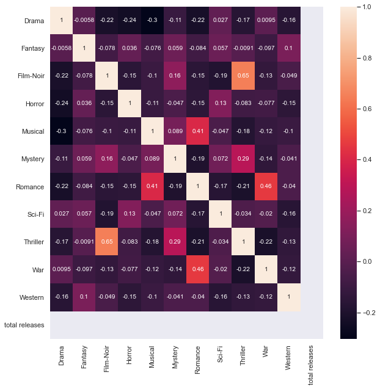

```python
plt.figure(figsize=(10,10))
sns.heatmap(percent_per_yr_per_gen.corr(),annot=True)
plt.show()
```

### 9. Find the top 25 movies according to average ratings such that each movie has number of ratings more than 100 - 10 marks

Hints :

1. Find the count of ratings and average ratings for every movie.
2. Slice the movies which have ratings more than 100.
3. Sort values according to average rating such that movie which highest rating is on top.
4. Select top 25 movies.
5. You will have to use the .merge() function to get the movie titles.

Note: This question will need you to research about groupby and apply your findings. You can find more on groupby on https://realpython.com/pandas-groupby/.

```python
#5. Merging both the datasets based on movie id in order to get the movie titles
movie_df = moviedata.merge(ratingdata, on="movie id", how = 'inner')
movie_df.head()
```

|  | movie id | movie title | release date | unknown | Action | Adventure | Animation | Childrens | Comedy | Crime | ... | Romance | Sci-Fi | Thriller | War | Western | Total_genre | release year | user id | rating | timestamp |
| --- | --- | --- | --- | --- | --- | --- | --- | --- | --- | --- | --- | --- | --- | --- | --- | --- | --- | --- | --- | --- | --- |
| 0 | 1 | Toy Story | 1995-01-01 | 0 | 0 | 0 | 1 | 1 | 1 | 0 | ... | 0 | 0 | 0 | 0 | 0 | 3 | 1995 | 308 | 4 | 887736532 |
| 1 | 1 | Toy Story | 1995-01-01 | 0 | 0 | 0 | 1 | 1 | 1 | 0 | ... | 0 | 0 | 0 | 0 | 0 | 3 | 1995 | 287 | 5 | 875334088 |
| 2 | 1 | Toy Story | 1995-01-01 | 0 | 0 | 0 | 1 | 1 | 1 | 0 | ... | 0 | 0 | 0 | 0 | 0 | 3 | 1995 | 148 | 4 | 877019411 |
| 3 | 1 | Toy Story | 1995-01-01 | 0 | 0 | 0 | 1 | 1 | 1 | 0 | ... | 0 | 0 | 0 | 0 | 0 | 3 | 1995 | 280 | 4 | 891700426 |
| 4 | 1 | Toy Story | 1995-01-01 | 0 | 0 | 0 | 1 | 1 | 1 | 0 | ... | 0 | 0 | 0 | 0 | 0 | 3 | 1995 | 66 | 3 | 883601324 |

5 rows × 27 columns

```python
#1.Count of number of movie ratings in each rating category
movie_df.groupby('movie id')['rating'].value_counts()
```

```
movie id  rating
1         4         202
          5         119
          3          96
          2          27
          1           8
                   ...
1678      1           1
1679      3           1
1680      2           1
1681      3           1
1682      3           1
Name: rating, Length: 6709, dtype: int64
```

```python
#1.Count of number of ratings for movies in descending order
high_numbersof_ratings = movie_df.groupby('movie title').size().sort_values(ascending=False)
high_numbersof_ratings
```

```
movie title
Star Wars              583
Contact                509
Fargo                  508
Return of the Jedi     507
Liar Liar              485
                      ...
Here Comes Cookie        1
Hedd Wyn                 1
He Walked by Night       1
Hana-bi                  1
Lady of Burlesque        1
Length: 1657, dtype: int64
```

```python
#1.Average ratings of all the movies
movie_avg_ratings = movie_df.groupby('movie title').agg({'rating': [np.size, np.mean]})
movie_avg_ratings
```

| movie title | rating size | rating mean |
| --- | --- | --- |
| 'Til There Was You | 9 | 2.333333 |
| 1-900 | 5 | 2.600000 |
| 101 Dalmatians | 109 | 2.908257 |
| 12 Angry Men | 125 | 4.344000 |
| 187 | 41 | 3.024390 |
| ... | ... | ... |
| Young Guns | 101 | 3.207921 |
| Young Guns II | 44 | 2.772727 |
| Young Poisoner's Handbook, The | 41 | 3.341463 |
| Zeus and Roxanne | 6 | 2.166667 |
| Á köldum klaka (Cold Fever) | 1 | 3.000000 |

1657 rows × 2 columns

```python
#2.Slicing movies with ratings of atleast 100 or more
movies_with_100ratings = movie_avg_ratings['rating']['size'] >= 100
movies_with_100ratings
```

```
movie title
'Til There Was You                 False
1-900                              False
101 Dalmatians                      True
12 Angry Men                        True
187                                False
                                   ...
Young Guns                          True
Young Guns II                      False
Young Poisoner's Handbook, The     False
Zeus and Roxanne                   False
Á köldum klaka (Cold Fever)        False
Name: size, Length: 1657, dtype: bool
```

```python
#3.Sort values according to average rating such that movie which highest rating is on top.
movie_avg_ratings[movies_with_100ratings].sort_values([('rating', 'mean')], ascending=False)
```

| movie title | rating size | rating mean |
| --- | --- | --- |
| Close Shave, A | 112 | 4.491071 |
| Schindler's List | 298 | 4.466443 |
| Wrong Trousers, The | 118 | 4.466102 |
| Casablanca | 243 | 4.456790 |
| Shawshank Redemption, The | 283 | 4.445230 |
| ... | ... | ... |
| Spawn | 143 | 2.615385 |
| Event Horizon | 127 | 2.574803 |
| Crash | 128 | 2.546875 |
| Jungle2Jungle | 132 | 2.439394 |
| Cable Guy, The | 106 | 2.339623 |

338 rows × 2 columns

```python
4.# Selecting top 25 movies based on average rating with number of ratings more than 100
movie_avg_ratings[movies_with_100ratings].sort_values([('rating', 'mean')], ascending=False)[:25]
```

| movie title | rating size | rating mean |
| --- | --- | --- |
| Close Shave, A | 112 | 4.491071 |
| Schindler's List | 298 | 4.466443 |
| Wrong Trousers, The | 118 | 4.466102 |
| Casablanca | 243 | 4.456790 |
| Shawshank Redemption, The | 283 | 4.445230 |
| Rear Window | 209 | 4.387560 |
| Usual Suspects, The | 267 | 4.385768 |
| Star Wars | 583 | 4.358491 |
| 12 Angry Men | 125 | 4.344000 |
| Citizen Kane | 198 | 4.292929 |
| To Kill a Mockingbird | 219 | 4.292237 |
| One Flew Over the Cuckoo's Nest | 264 | 4.291667 |
| Silence of the Lambs, The | 390 | 4.289744 |
| North by Northwest | 179 | 4.284916 |
| Godfather, The | 413 | 4.283293 |
| Secrets & Lies | 162 | 4.265432 |
| Good Will Hunting | 198 | 4.262626 |
| Manchurian Candidate, The | 131 | 4.259542 |
| Dr. Strangelove or: How I Learned to Stop Worrying and Love the Bomb | 194 | 4.252577 |
| Raiders of the Lost Ark | 420 | 4.252381 |
| Vertigo | 179 | 4.251397 |
| Titanic | 350 | 4.245714 |
| Lawrence of Arabia | 173 | 4.231214 |
| Maltese Falcon, The | 138 | 4.210145 |
| Empire Strikes Back, The | 367 | 4.204360 |